# Entrega 9.

Estadistica Computacional. Curso 2021-2022.

Carlota Valdivia Manzano.

12 de Mayo de 2022.

## Ejercicio 1

Cargamos los datos de **hatco2.csv** almacenandolos en un dataframe con nombre hatco donde las variables de tipo *factor* se identifiquen como tal

```r
hatco<-read.csv(file="hatco2.csv",header=TRUE,stringsAsFactors=TRUE)
```

Primero representamos graficamente los datos para observar la posible relacion entre la respuesta y las variables explicativas

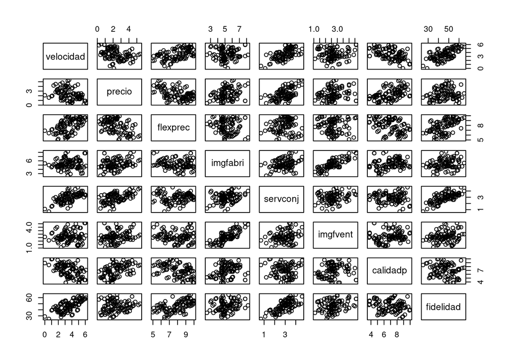

```r
plot(hatco[,c(6:13)])
```

Ajustamos el modelo de regresion lineal multiple a las n=100 observaciones

```r
mod1<-lm(fidelidad~velocidad+precio+flexprec+imgfabri+servconj+imgfvent+calidadp,hatco)
mod1
```

```
##
## Call:
## lm(formula = fidelidad ~ velocidad + precio + flexprec + imgfabri +
##     servconj + imgfvent + calidadp, data = hatco)
##
## Coefficients:
## (Intercept)    velocidad       precio     flexprec     imgfabri     servconj
##   -10.16148     -0.04352     -0.67891      3.36197     -0.04101      8.34537
##    imgfvent     calidadp
##     1.29147      0.56295
```

Vamos a calcular el contraste de regresion y los coeficientes de determinacion con la funcion summary.

```r
summary(mod1)
```

```
##
## Call:
## lm(formula = fidelidad ~ velocidad + precio + flexprec + imgfabri +
##     servconj + imgfvent + calidadp, data = hatco)
##
## Residuals:
##      Min       1Q   Median       3Q      Max
## -12.9759  -1.9491   0.5896   2.8144   6.7565
##
## Coefficients:
##              Estimate Std. Error t value Pr(>|t|)
## (Intercept) -10.16148    4.97696  -2.042   0.0440 *
## velocidad    -0.04352    2.01273  -0.022   0.9828
## precio       -0.67891    2.09025  -0.325   0.7461
## flexprec      3.36197    0.41125   8.175 1.56e-12 ***
## imgfabri     -0.04101    0.66683  -0.061   0.9511
## servconj      8.34537    3.91830   2.130   0.0359 *
## imgfvent      1.29147    0.94720   1.363   0.1761
## calidadp      0.56295    0.35544   1.584   0.1167
## ---
## Signif. codes:  0 '***' 0.001 '**' 0.01 '*' 0.05 '.' 0.1 ' ' 1
##
## Residual standard error: 4.424 on 92 degrees of freedom
## Multiple R-squared:  0.775,  Adjusted R-squared:  0.7578
## F-statistic: 45.26 on 7 and 92 DF,  p-value: < 2.2e-16
```

Calculamos la tabla **ANOVA**.

```r
anova(mod1)
```

```
## Analysis of Variance Table
##
## Response: fidelidad
##           Df Sum Sq Mean Sq  F value    Pr(>F)
## velocidad  1 3659.8  3659.8 187.0071 < 2.2e-16 ***
## precio     1  927.9   927.9  47.4128 6.932e-10 ***
## flexprec   1 1346.3  1346.3  68.7912 8.779e-13 ***
## imgfabri   1  100.4   100.4   5.1311   0.02585 *
## servconj   1   71.5    71.5   3.6517   0.05913 .
## imgfvent   1   44.9    44.9   2.2963   0.13311
## calidadp   1   49.1    49.1   2.5084   0.11667
## Residuals 92 1800.5    19.6
## ---
## Signif. codes:  0 '***' 0.001 '**' 0.01 '*' 0.05 '.' 0.1 ' ' 1
```

### Significacion individual de las variables explicativas

Para x<sub>1</sub> no hay evidencia suficiente para rechazar la hip nula al 5% de significacion.

Repetimos el procedimiento anterior para otras percepciones *x<sub>2</sub>…x<sub>7</sub>*.

Las únicas percepciones para las que se rechazan la hipotesis nula al 5% de significacion son:

- *flexprec* y *servconj*, ya que sus p-valores se quedan por debajo de 0.05

Para el resto de percepciones no evidencia suficiente de los datos para rechazar la hipotesis nula al 5% de significacion, por lo que la percepcion del cliente ante dichas percepciones no parece influir significativamente en su fidelidad.

### Significacion del termino constante

Con el 5% no podríamos presencidir del termino constante en el modelo ya que su p-valor es 0.044, en cambio para el 1% si se podria

### Homocedasticidad

Calculamos los residuos

```r
residuos<-rstandard(mod1)
y_gorro<-mod1$fitted.values
```

Representamos el grafico de dispersion de los pares *(y_gorro,residuos)*.

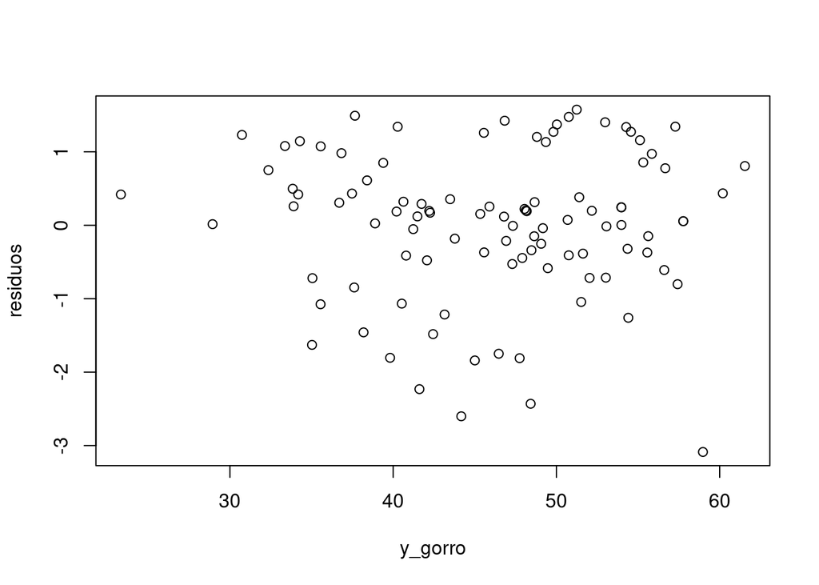

```r
plot(y_gorro,residuos)
```

Representamos para cada percepcion x_j los grafos de dispersion de los pares (x_ij,r_i).

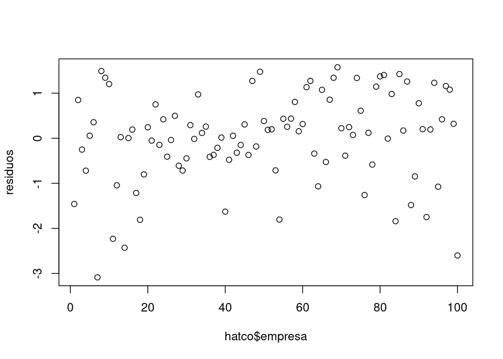

```r
plot(hatco$empresa, residuos)
```

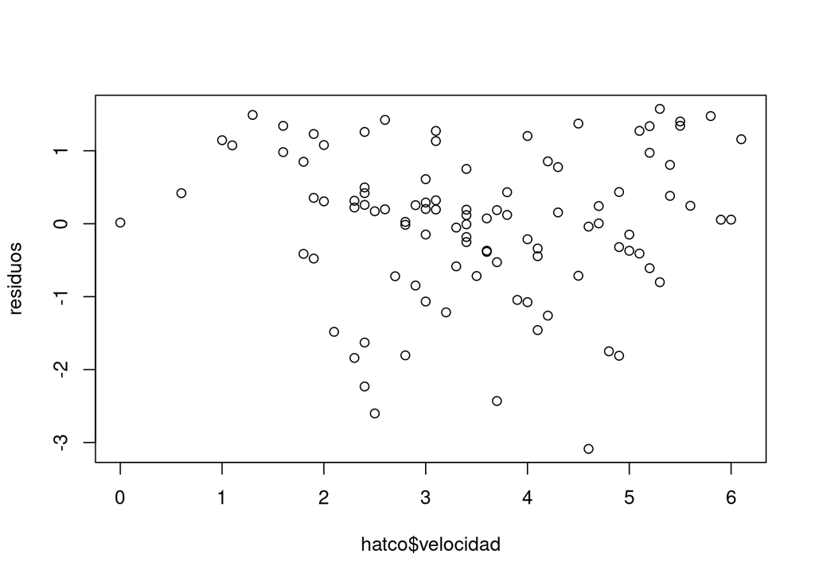

```r
plot(hatco$velocidad, residuos)
```

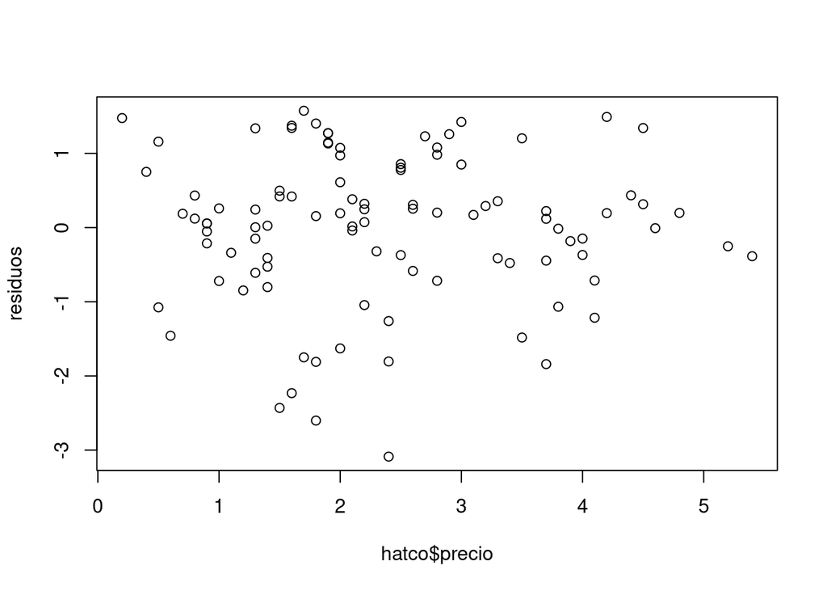

```r
plot(hatco$precio, residuos)
```

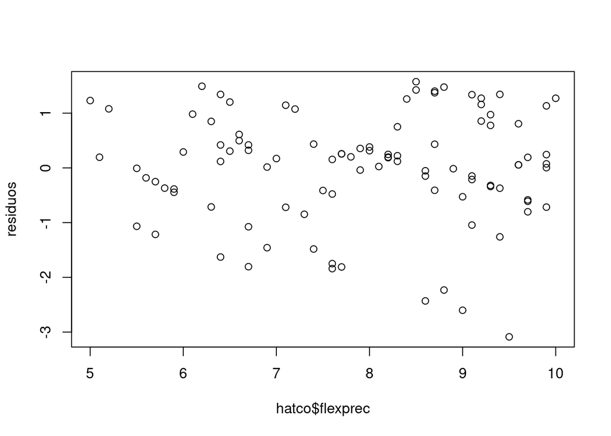

```r
plot(hatco$flexprec, residuos)
```

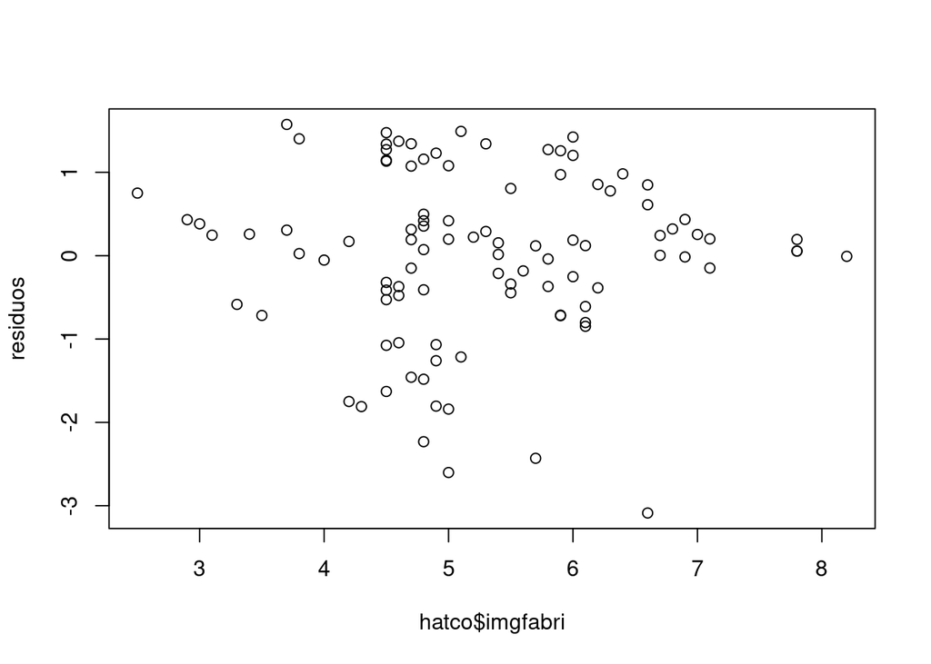

```r
plot(hatco$imgfabri, residuos)
```

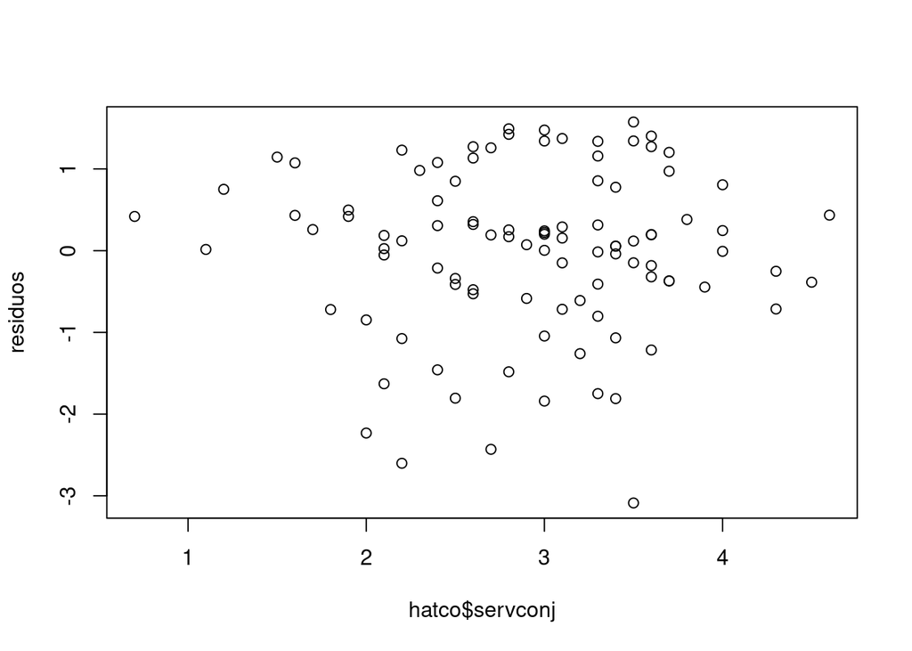

```r
plot(hatco$servconj, residuos)
```

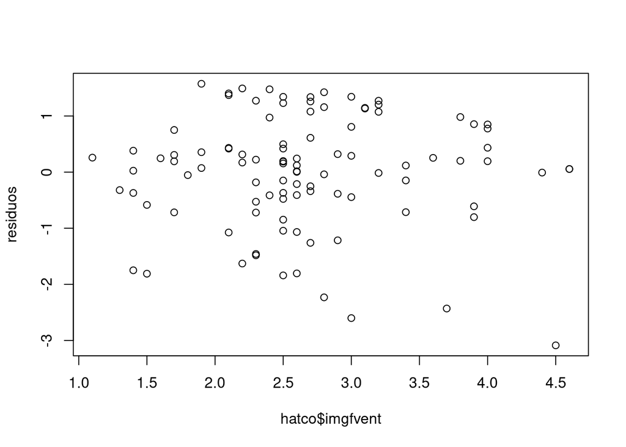

```r
plot(hatco$imgfvent, residuos)
```

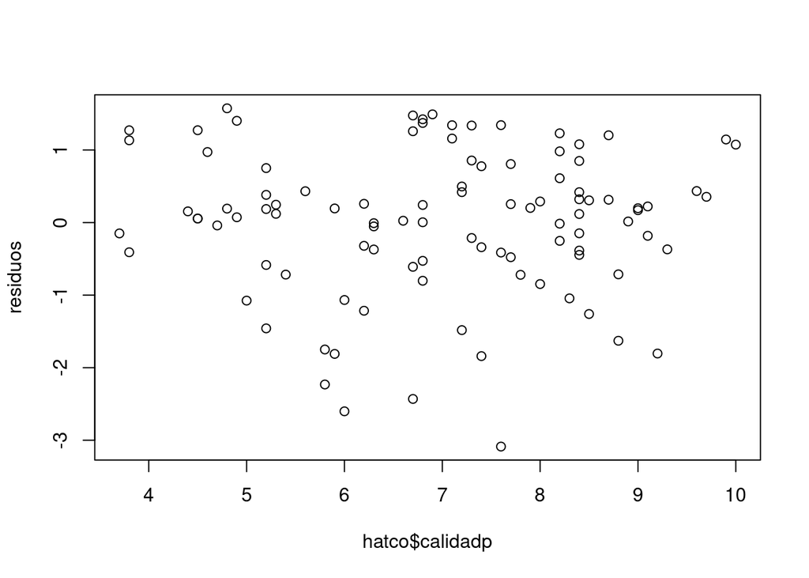

```r
plot(hatco$calidadp, residuos)
```

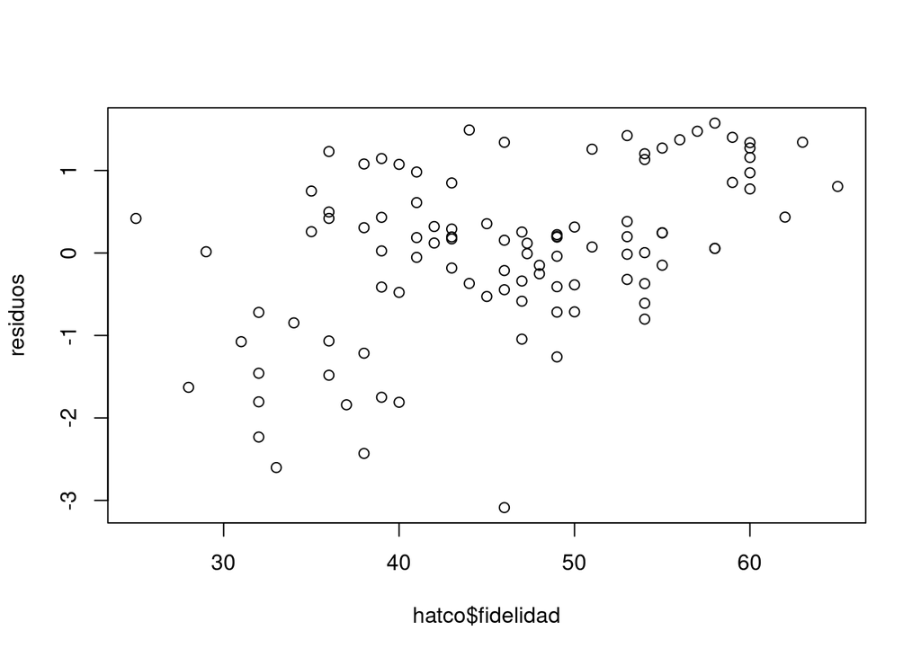

```r
plot(hatco$fidelidad, residuos)
```

Podemos observar que no hay ningun patron excepto en el ultimo grafico.

Borramos memoria.

```r
rm(list=ls(all=TRUE))
```